# Rethinking Rainfall and Storm Surge

07/11/2019

## Dutchsplaining

## Polders and Canals

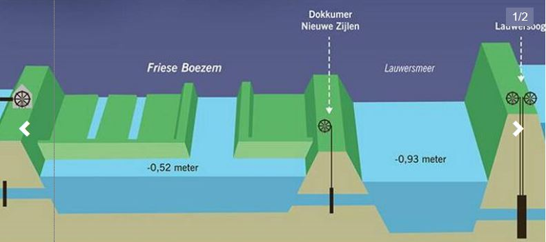

## Wetterskip Fryslân

[interactive chart not shown]

## Sluices

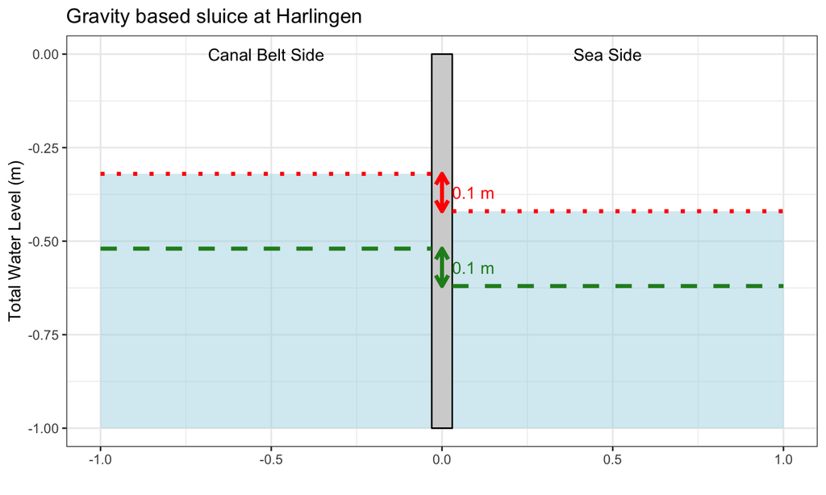

—- Risk level to be avoided -0.32 m  
Normal operating level -0.52 m

## Compound Events

## Rainfall-Surge Mechansims

Three compound types that increase the flood risk:  
(Wahl et al. 2015)

**Mechanism (1): Both Extreme** the joint occurrence elevates water levels

## Rainfall-Surge Mechansims

Three compound types that increase the flood risk:  
(Wahl et al. 2015)

**Mechanism (1): Both Extreme** the joint occurrence elevates water levels

**Mechanism (2): Extreme Surge** causing flooding, combined with any additional rainfall - even if it is not an extreme

## Rainfall-Surge Mechansims

Three compound types that increase the flood risk:  
(Wahl et al. 2015)

**Mechanism (1): Both Extreme** the joint occurrence elevates water levels

**Mechanism (2): Extreme Surge** causing flooding, combined with any additional rainfall - even if it is not an extreme

**Mechanism (3): Heavy/Extreme Rainfall** combined with a moderate storm surge that prevents discharge of rainfall run-off using gravity-fed drainage

## Side comment

**Mechanism (1): Both Extreme**  
The dependence relationship between storm surge height and rainfall amount is very weak!  
(Zheng et al. 2014, Bevacqua et al. 2019)

## Risk Duration and Height Surge

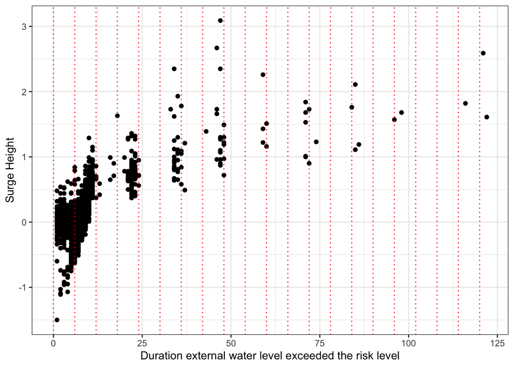

## Reality for Compound Risk

**Don't really care how big the surge is**

[interactive chart not shown]

[via GIPHY](https://giphy.com/gifs/wtf-obama-wth-pPhyAv5t9V8djyRFJH)

## Actually interested in

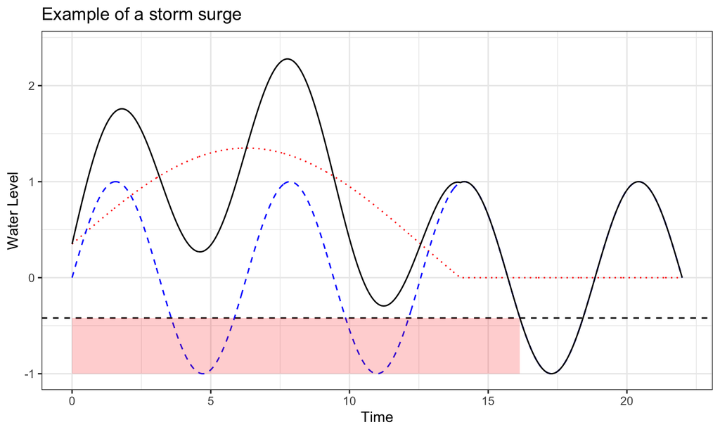

Total water level ———- Harmonic Tide ——— Storm Surge

## Event Based Approach

## Objective

**Want to forecast timing or duration dependent variables**

## Objective

**Want to forecast timing or duration dependent variables**  
**and evaluate how good these forecasts are**

## Ensemble: Storm Surge Trajectories

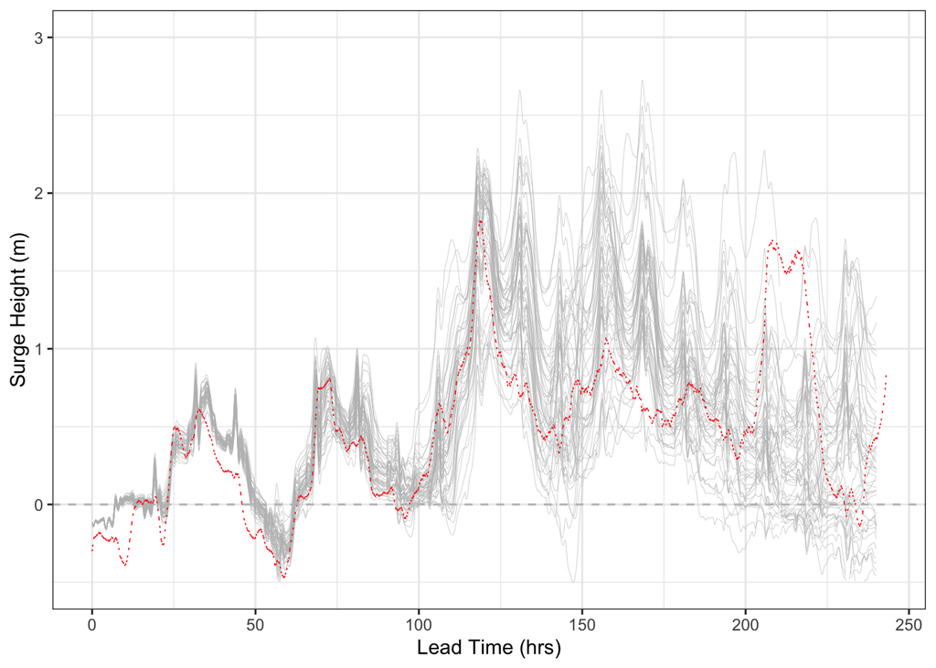

## Trajectories Features

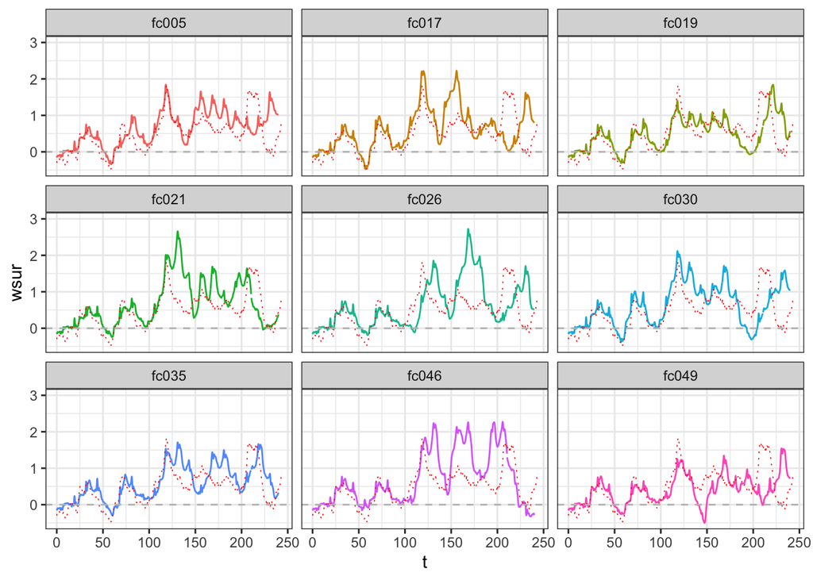

## Forecast Features

In some forecast window \(K\):

- Does the storm surge peak after time \(T\)?

\[g(t; k) = \mathbb{1}\left(\displaystyle{\text{argmax}_{k \in K}} \left( S_{t+k} \right) > T \right)\]

- Is the maximum height of the storm surge greater than \(S\)?

\[g(t; k) = \mathbb{1}\left( \displaystyle{\text{max}_{k \in K}} \left( S_{t+k} \right) > S \right)\]

- Is the storm surge duration longer than duration \(D\)?

\[g(t; k) = \mathbb{1}\left\lbrace \left( \tfrac{1}{K\Delta{k}}\sum_{k \in K} \mathbb{1}\left(S_{t+k} > 0 \right)\right) > D \right\rbrace\]

## Forecast Features ctd.

- Is duration the total level is above a risk threshold, \(r\), greater than \(D\)?

\[g(t; k, r) = \mathbb{1}\left\lbrace \left( \tfrac{1}{K\Delta{k}}\sum_{k \in K} \mathbb{1}\left(S_{t+k} + h_{t+k} > r \right) \right) > D \right\rbrace\]

## Ensemble: Total Level

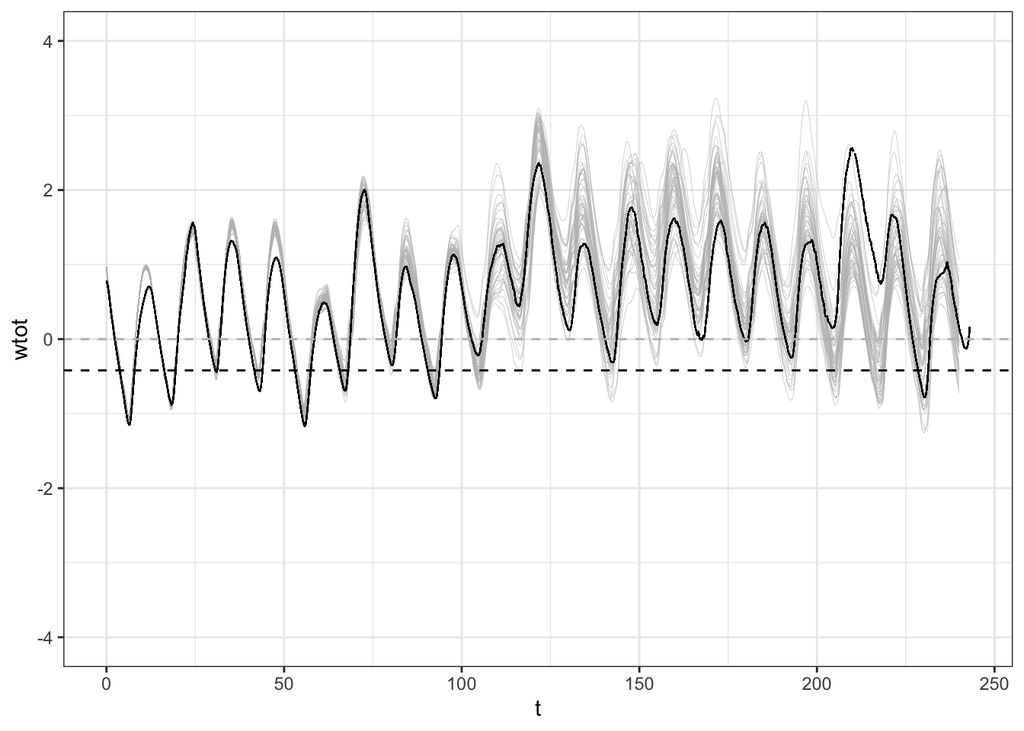

## Risk Duration

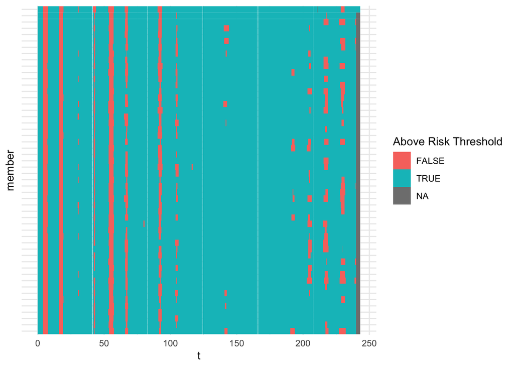

## Scoring

The probability of a given event can then be estimated from the \(M\) ensemble members:

\[ P_t \left[g(t, \theta)\right] = \tfrac{1}{M} \sum_{m=1}^M g^{(m)}(t, \theta), \]

Pinson et al. (2012) suggests using a Brier Score (BS):

\[BS = \dfrac{1}{T} \sum_{t = 1}^T \left( P_t \left[ g(t, \theta) \right] - g( t, \theta ) \right) ^2\]

## Windows Example

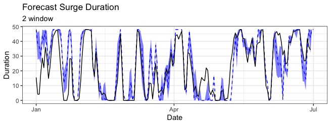

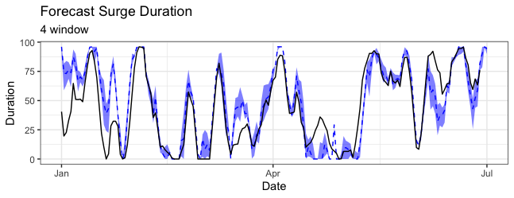

## Careful

In an event based approach -  
**directly applying the BS can violate some basic statistical assumptions**

## Careful

In an event based approach -  
**directly applying the BS can violate some basic statistical assumptions**

Dates in the windows overlap:  
\(\quad\Rightarrow\) careful forecasts are independent  
\(\quad\Rightarrow\) scoring ignores autocorrelation

## Careful

In an event based approach -  
**directly applying the BS can violate some basic statistical assumptions**

Dates in the windows overlap:  
\(\quad\Rightarrow\) careful forecasts are independent  
\(\quad\Rightarrow\) scoring ignores autocorrelation

More variability at longer lead times:  
\(\quad\Rightarrow\) problem for larger windows  
\(\quad\Rightarrow\) ignores heteorskadiscity

## Risk categories

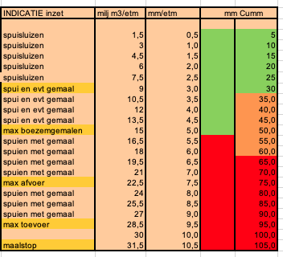

## Conclusions

- For stakeholders event based information is very **important**
- How we score temporal events isn't necessary straightforward
- Scoring choices are likely application dependent